# Project: Communicate Data findings

## Overview

This project involves exploratory data visualization. Python libraries were used to visualize and systematically explore a selected dataset, starting from plots of single variables and building up to plots of multiple variables.

The data set selected is a US bank's loan containing different attributes that describes customer. The major aim is to explore the different attributes to identify pattern that describes a fully paid loan and charged off loans

### How big is the dataset ?

```
(18324, 31)
```

## To undederstand the behaviour of different variables within the data, we performed some visualization

# Univariate Visualization

## Question: what is the distribution of the customers across the different states in US

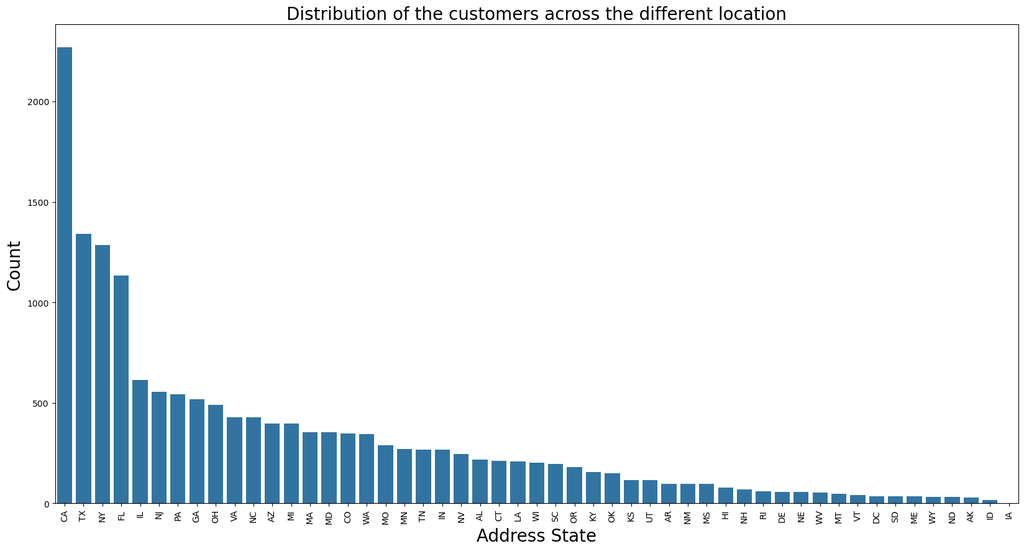

## Question: what is the distribution of the different employment length among the customers ?

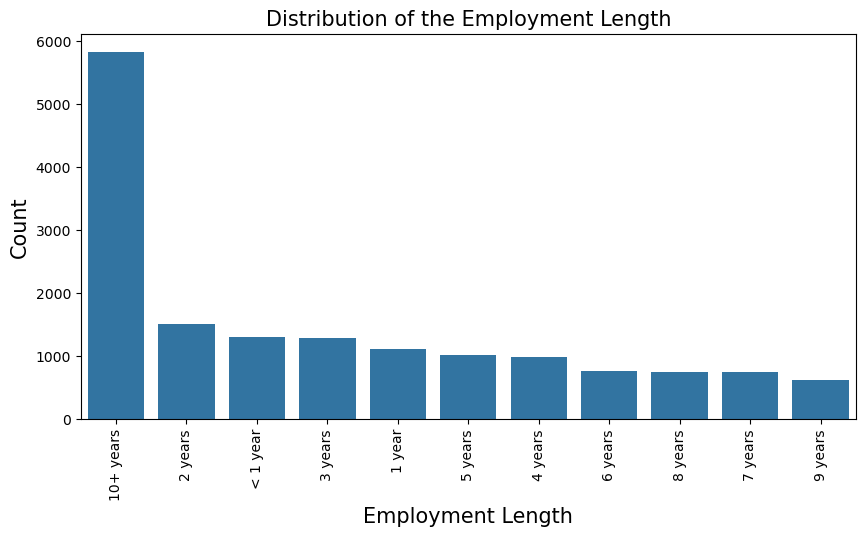